# homework_03_template_python (3)

## CMPINF 2130 Summer 2023 - Homework 03

### Assigned June 1, 2023; Due June 8, 2023

### Submission time: June 8, 2023 11:00PM EST

#### Collaborators

Include the names of other students you worked with here.

## Overview

You will work with 3 data sets in this assignment. Two of the data sets will be explored in both R and Python. This allows you to direclty compare figures between the two languages. Two of the data sets are new while the third is a data set from the previous assignment. You will practice lumping low frequency counts in this assignment and consider the consequences of such actions. You will also practice visualizing continuous distributions using synthetic and real data.

The three data sets for this assignment are:

- Western Pennsylvania Interscholastic Athletic League (WPIAL) Baseball Champions
  - All WPIAL Baseball Champions dating back to 1979
  - Problems 01 and 02 are associated with the WPIAL data
- Synthetic data created for this assignment to practice visualizing continuous distributions
  - 9 variables are included to give you practice visualizing different distributional shapes!
  - Problem 03 is associated with the synthetic data
- The EPA Air Quality System (AQS) data from homework 02
  - You will explore the continuous variable `daily_avg` in this assignment
  - Problems 04 and 05 are associated with the EPA AQS data

You will explore the WPIAL and synthetic data in both R and Python. The EPA AQS data will only be explored in R.

The last problem, Problem 06, requires you to read in potential data for your final project. You may answer this problem in either Python or R.

The problem numbering in the Jupyter notebook is consistent with the R numbering. The Jupyter notebook therefore does **NOT** include Problems 04 and 05.

**Important**: Please download all CSV files from the Canvas site and save them in the same directory as your RMarkdown file. The code chunks read in the CSV files assuming they are in the same directory.

## Problem 00

**Import the 4 Python modules NumPy, Pandas, Matplotlib Pyplot, and Seaborn. You must use the commonly accepted aliases for the modules.**

#### SOLUTION

```python
import numpy as np
import pandas as pd
import matplotlib.pyplot as plt
import seaborn as sns
```

## Problem 01

The WPIAL is the Highschool athletic league in Western Pennsylvania. Each year Highschools across Western PA compete to win the Western PA title and move on to the State championship. For Baseball, the WPIAL is divided into multiple classes based on Highschool district size. Schools with fewer students compete in Class 1A while the largest Schools compete in 6A. The WPIAL Baseball Champions data are read in for you in the cell below. The data are assigned to the `wpial` object. There are three columns in the data set:

- `Year`: The year the competition was played
- `Class`: The Class designation (School size)
- `School`: The name of the School that won the championship

The data you are working with does not consist of all WPIAL winners. You are working with data starting from 1979 even though the first WPIAL Baseball championship took place in 1914. You are working with more recent data because school districts were very different over 100 years ago.

```python
wpial = pd.read_csv('wpial_baseball_champs.csv')
```

### 1a)

**Use `.info()` to check the number of rows, columns, and data types of the columns in `wpial`.**

#### SOLUTION

```python
wpial.info()
```

```
<class 'pandas.core.frame.DataFrame'>
RangeIndex: 142 entries, 0 to 141
Data columns (total 3 columns):
 #   Column  Non-Null Count  Dtype
---  ------  --------------  -----
 0   Year    142 non-null    int64
 1   Class   142 non-null    object
 2   School  142 non-null    object
dtypes: int64(1), object(2)
memory usage: 3.5+ KB
```

### 1b)

**Create a bar chart to show the counts for the `Class` variable using Seaborn.**

#### SOLUTION

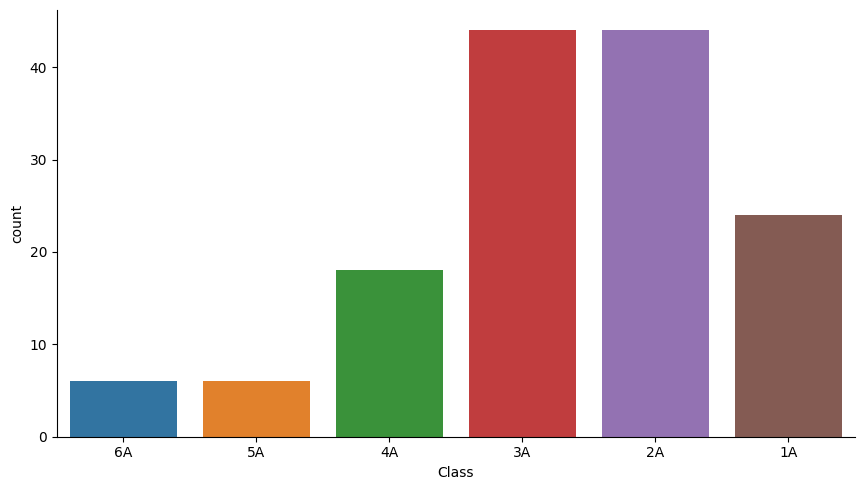

```python
sns.catplot(data = wpial, x ='Class', kind = 'count', aspect = 1.75)
plt.show()
```

### 1c)

**Which Class has the most rows?**

**Which class has the fewest rows?**

#### SOLUTION

Classes 3A and 2A have the most rows and Classes 5A and 6A have the fewest rows

### 1d)

**Create a bar chart to show the counts for the `School` variable using Seaborn. The names should be relatively easy to read.**

#### SOLUTION

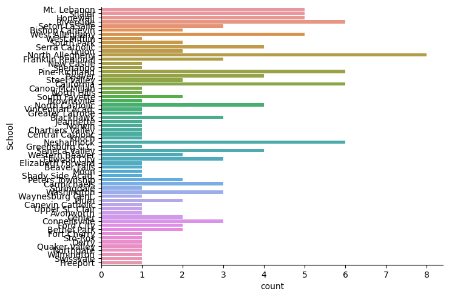

```python
sns.catplot(data = wpial, y ='School', kind = 'count', aspect = 1.5)
plt.show()
```

### 1e)

**Create a bar chart to show the counts for the `School` variable in Seaborn again. However, this time the bar chart MUST be in ASCENDING frequency order. The names should be relatively easy to read.**

#### SOLUTION

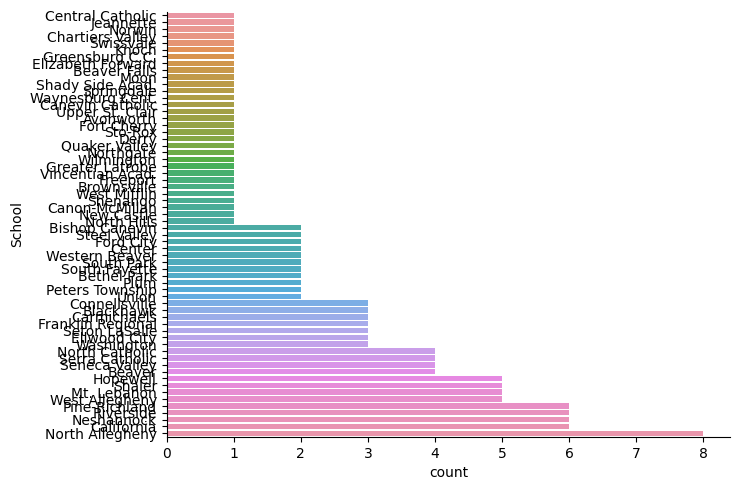

```python
sns.catplot(data = wpial, y ='School', kind = 'count', aspect = 1.5,
            order = wpial['School'].value_counts(ascending= True).index)
plt.show()
```

### 1f)

Let's now consider the combination of `School` and `Class`.

**Create a STACKED bar chart to show the counts of the `School` variable. The bar `hue` must be associated with the `Class` variable. The bar chart must be in ASCENDING frequency order. The names should be relatively easy to read.**

**You may use the default color palette.**

#### SOLUTION

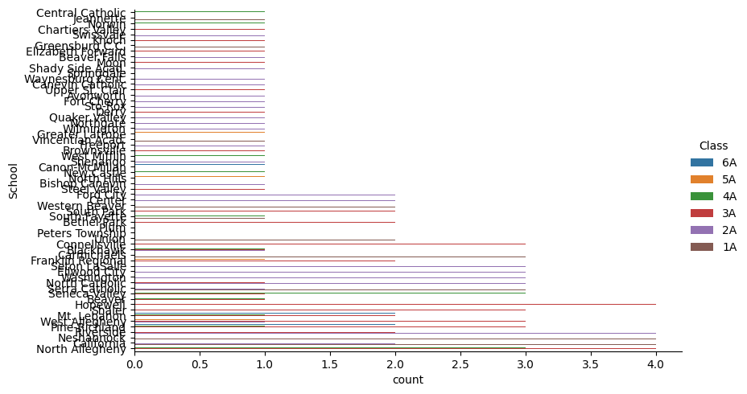

```python
sns.catplot(data = wpial,y ='School', hue = 'Class', kind = 'count', aspect = 1.75,
           order = wpial['School'].value_counts(ascending= True).index)

plt.show()
```

### 1g)

Let's now consider the combinations of `School` and `Class` using a heat map.

**Create a heat map to show the combinations of `School` and `Class`. The count must also be annotated via text.**

#### SOLUTION

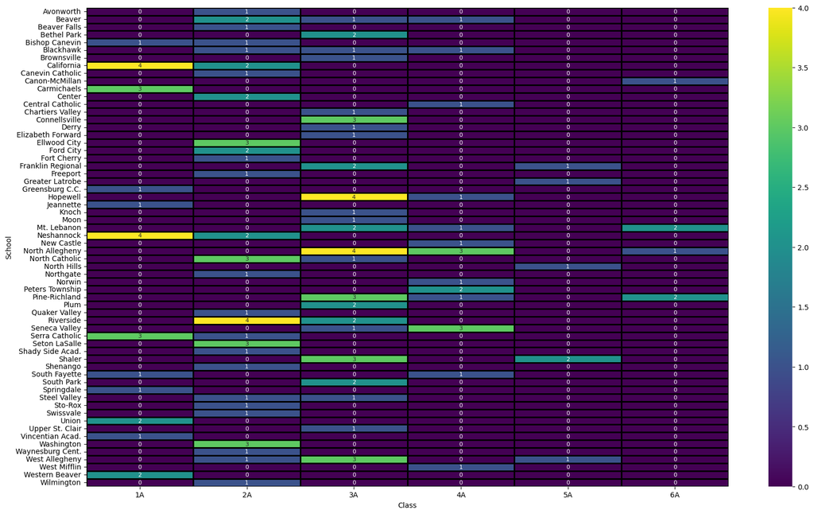

```python
fig, ax = plt.subplots(figsize=(20, 12))
sns.heatmap(data = pd.crosstab(wpial.School, wpial['Class']),
            annot = True,
            annot_kws={'size': 8},
            cmap = 'viridis',
            linecolor = 'k', linewidths = 0.85,
           ax=ax)

plt.show()
```

### 1h)

**How many different `Class` championships have been won by the `School` with the most total WPIAL championships?**

#### SOLUTION

```python
data = pd.crosstab(wpial.School, wpial['Class'])

# Sum all the columns and assign it to a new column 'Total'
data['Total'] = data.sum(axis=1)
max = data['Total'].max()
print(data)
print(max)
```

```
Class             1A  2A  3A  4A  5A  6A  Total
School
Avonworth          0   1   0   0   0   0      1
Beaver             0   2   1   1   0   0      4
Beaver Falls       0   1   0   0   0   0      1
Bethel Park        0   0   2   0   0   0      2
Bishop Canevin     1   1   0   0   0   0      2
...               ..  ..  ..  ..  ..  ..    ...
Waynesburg Cent.   0   1   0   0   0   0      1
West Allegheny     0   1   3   0   1   0      5
West Mifflin       0   0   0   1   0   0      1
Western Beaver     2   0   0   0   0   0      2
Wilmington         0   1   0   0   0   0      1

[62 rows x 7 columns]
8
```

```python
data = pd.crosstab(wpial.School, wpial['Class'])

# Find the maximum number in the table
max_number = data.max().max()

# Find the row(s) with the maximum number
max_row = data[data == max_number].index

# Count the number of other entries in the same row(s)
others_count = data.loc[max_row].sum(axis=1)
others_count.max()
```

```
8
```

### 1i)

**How many schools have won a single WPIAL championship?**

#### SOLUTION

```python
data = pd.crosstab(wpial.School, wpial['Class'])
```

```python
num_ones = (data == 1).sum().sum()

print("Number of 1s:", num_ones)
```

```
Number of 1s: 52
```

```python
data
```

| Class School | 1A | 2A | 3A | 4A | 5A | 6A |
| --- | --- | --- | --- | --- | --- | --- |
| Avonworth | 0 | 1 | 0 | 0 | 0 | 0 |
| Beaver | 0 | 2 | 1 | 1 | 0 | 0 |
| Beaver Falls | 0 | 1 | 0 | 0 | 0 | 0 |
| Bethel Park | 0 | 0 | 2 | 0 | 0 | 0 |
| Bishop Canevin | 1 | 1 | 0 | 0 | 0 | 0 |
| ... | ... | ... | ... | ... | ... | ... |
| Waynesburg Cent. | 0 | 1 | 0 | 0 | 0 | 0 |
| West Allegheny | 0 | 1 | 3 | 0 | 1 | 0 |
| West Mifflin | 0 | 0 | 0 | 1 | 0 | 0 |
| Western Beaver | 2 | 0 | 0 | 0 | 0 | 0 |
| Wilmington | 0 | 1 | 0 | 0 | 0 | 0 |

62 rows × 6 columns

## Problem 02

Hopefully you have seen that there are many different Schools in the data set! We learned that LUMPING low frequency categories can help simplify figures when there are a large number of categories. However, it is critical to consider the consequence of such actions! Let's see what those consequences could be with WPIAL data set.

**Please note the instructions for this problem are slightly different from those in the R version of the assignment.**

### 2a)

There are multiple lumping procedures that you could consider, but let's use a simple one in this assignment. You will lump based on a PROPORTION threshold. All LEVELS or CATEGORIES with LESS THAN a THRESHOLD proportion will be LUMPED into an OTHER category. The Python reading associated with Week 03 demonstrated how to define a function which lumped low frequency categories based on a proportion threshold. You must use that function for this problem.

**Define the lumping function `fct_lump_prop()` in the cell below.**

#### SOLUTION

```python
def fct_lump_prop(df, col, prop, other_name = '(OTHER)'):
    the_props = df[col].value_counts(normalize=True)
    the_mask = the_props < 0.01
    lump_values = the_props[ the_mask ].index.tolist()

    new_col = pd.Series(np.where( df[col].isin( lump_values ), other_name, df[col] ), index=df.index)

    return new_col
```

```python
fct_lump_prop(wpial, 'School', 0.01, other_name = '(OTHER)')
```

```
0        Mt. Lebanon
1             Shaler
2           Hopewell
3          Riverside
4      Seton LaSalle
           ...
137          (OTHER)
138           Shaler
139          (OTHER)
140         Hopewell
141          (OTHER)
Length: 142, dtype: object
```

### 2b)

In lecture, we used a proportion threshold of 5%. However, **you will use a proportion threshold of 1% in this assignment.**

**Lump the low frequency categories of `School` into an OTHER category. Name the OTHER category `'(OTHER)'`. Assign the lumped schools to a new column within the `wpial` DataFrame named `lump_school`.**

**Apply the `.value_counts()` method to the `lump_school` column and display the results to the screen.**

#### SOLUTION

```python
fct_lump_prop(wpial, 'School', 0.01, other_name = '(OTHER)').value_counts()
```

```
(OTHER)              31
North Allegheny       8
California            6
Neshannock            6
Riverside             6
Pine-Richland         6
Shaler                5
Mt. Lebanon           5
Hopewell              5
West Allegheny        5
Beaver                4
North Catholic        4
Serra Catholic        4
Seneca Valley         4
Carmichaels           3
Franklin Regional     3
Connellsville         3
Seton LaSalle         3
Blackhawk             3
Washington            3
Ellwood City          3
Ford City             2
Center                2
Plum                  2
South Park            2
Peters Township       2
Western Beaver        2
South Fayette         2
Steel Valley          2
Bishop Canevin        2
Union                 2
Bethel Park           2
dtype: int64
```

```python
the_props = wpial['School'].value_counts(normalize=True)
```

```python
the_mask = the_props < 0.01
```

```python
wpial['lump_School'] = pd.Series( np.where(wpial['School'].isin( the_props[ the_mask ].index.tolist() ), '(OTHER)', wpial['School'] ),
                              index=wpial.index)
```

### 2c)

**Visualize the counts of the `lump_school` variable via a bar chart in Seaborn. The bar chart must be in ASCENDING frequency order. The names should be relatively easy to read.**

#### SOLUTION

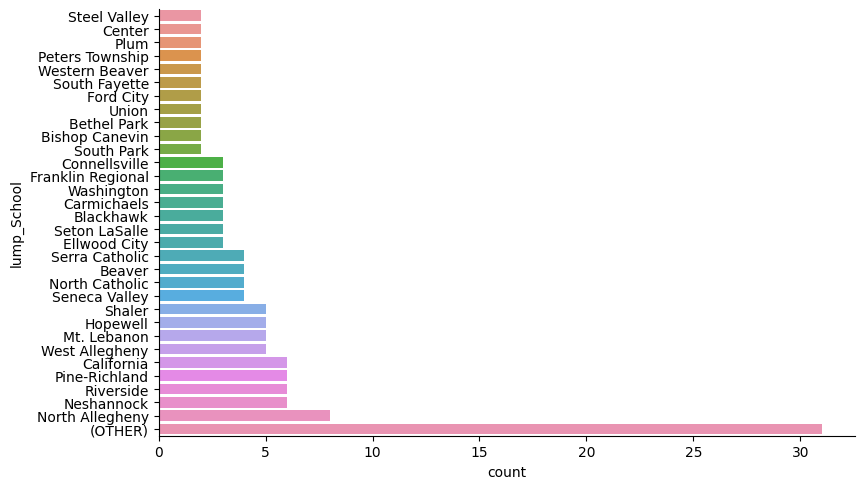

```python
sns.catplot(data = wpial, y='lump_School', kind='count', aspect=1.75,
            order = wpial.lump_School.value_counts(ascending=True).index)

plt.show()
```

### 2d)

You will now visualize the combinations of `lump_school` with `Class` via a heat map.

**Create a heat map to show the combinations of `lump_school` and `Class`. The count must also be annotated via text.**

#### SOLUTION

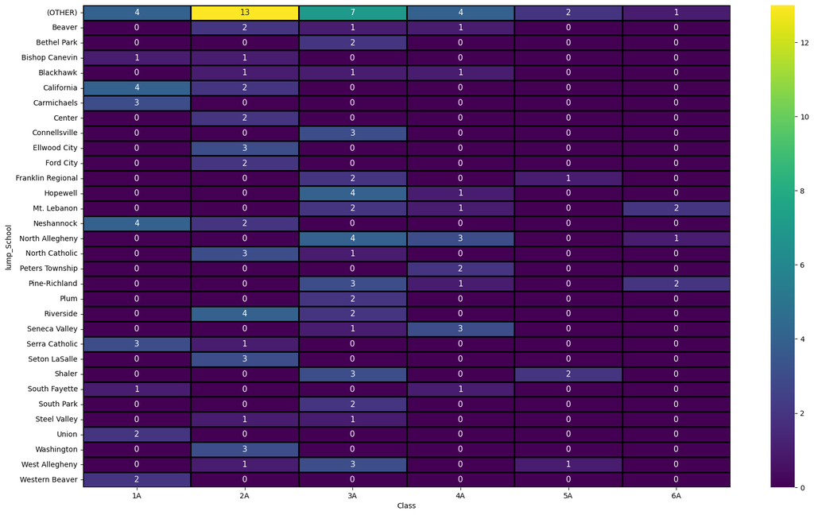

```python
fig, ax = plt.subplots(figsize=(20, 12))
sns.heatmap(data = pd.crosstab(wpial.lump_School, wpial['Class']),
            annot = True,
            annot_kws={'size': 11},
            cmap = 'viridis',
            linecolor = 'k', linewidths = 0.85,
           ax=ax)

plt.show()
```

### 2e)

**How would you describe the impact of the LUMPING procedure? Did it help? Did it modify the organizational nature of the `School` categories?**

#### SOLUTION

The LUMPING procedure helped in consolidating or grouping similar categories together, resulting in a modification of the organizational nature of the School categories. It aimed to reduce the complexity and improve the interpretability of the data by combining related categories into `other` group. This process can help in simplifying the analysis and providing a clearer understanding of the data patterns and relationships.

### 2f)

You executed the lumping within this assignment based on a proportion threshold dictated to you. In practice, you should always consider the category proportions BEFORE using an assumed threshold.

**Visualize the proportion bar chart for `School` without lumping. The bar chart must be in ASCENDING order. The names should be relatively easy to read.**

#### SOLUTION

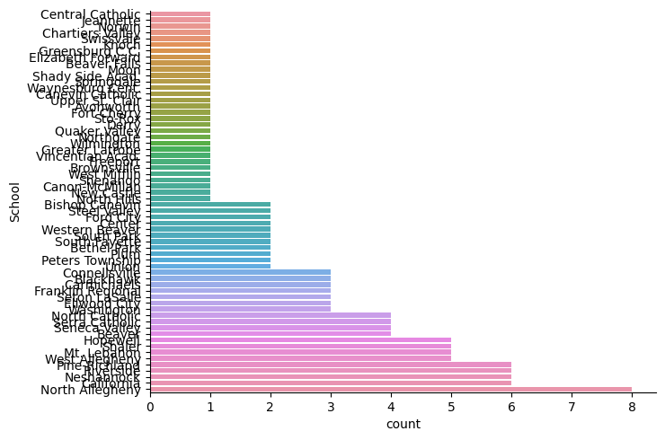

```python
sns.catplot(data = wpial, y ='School', kind = 'count', aspect = 1.5,
            order = wpial.School.value_counts(ascending=True).index)
plt.show()
```

### 2g)

**Why does the figure in 2f) explain what happened with the LUMPING procedure?**

#### SOLUTION

Because after lumping we changed the dataset and never reset it

## Problem 03

You will now explore continuous variable distributions. You will do so using synthetic data generated for this assignment. The synthetic data are read in for you in the cell below and assigned to the `df` object. There are 9 continuous variables in the data set. These 9 variables were randomly generated using distributions that you will commonly encounter in data analysis tasks. Thus, exploring these 9 variables will prepare you for common challenges you will experience when exploring continuous variables.

```python
df = pd.read_csv('hw03_synthetic.csv')
```

```python
df.head()
```

|  | x1 | x2 | x3 | x4 | x5 | x6 | x7 | x8 | x9 |
| --- | --- | --- | --- | --- | --- | --- | --- | --- | --- |
| 0 | 8.120639 | 9.960223 | 9.047559 | 1.505284 | 2.743911 | 2.484310 | 0.894181 | 2.345805 | 0.084014 |
| 1 | 10.550930 | 14.826853 | 13.590404 | 2.376810 | 0.517339 | 3.062525 | 0.891118 | 0.417396 | 0.964658 |
| 2 | 7.493114 | 10.615168 | 27.412923 | 1.754423 | 1.352082 | 0.438285 | 0.745600 | 0.607207 | 0.094535 |
| 3 | 14.785842 | 5.542776 | 13.446587 | 7.392501 | 1.390951 | 1.187305 | 0.921417 | 1.957724 | 0.099087 |
| 4 | 10.988523 | 9.304117 | 15.069754 | 1.702202 | 0.693555 | 1.351187 | 0.925357 | -2.530705 | 0.823119 |

This problem is more open ended compared to others. You must create the following visualizations for EACH variable within `df`.

- Histogram using an appropriate number of bins which includes KDE and RUG
- eCDF

**NOTE**: Fewer figures are required for the Python portion of the assignment compared to the R portion.

You must insert all cells. Your solutions must be well organized and easy to follow, but you may organize the code however you see fit. You **CANNOT** use any modules outside of the 4 modules we used in lecture to create the figures.

You **must** also answer the following conceptual questions for each variable:

- Does the distribution look like a symmetric bell-curve?
- Does the eCDF look like the Gaussian eCDF visualized in the Week 03 reading?

You may use for-loops to aid in the creation of the figures but that is not required. I would not use for-loops if I was in your shoes! It should be OBVIOUS which variable you are visualizing and discussing in your response.

*HINT*: The Week 03 readings will greatly help with this problem.

#### SOLUTION

```python
len(df)
```

```
375
```

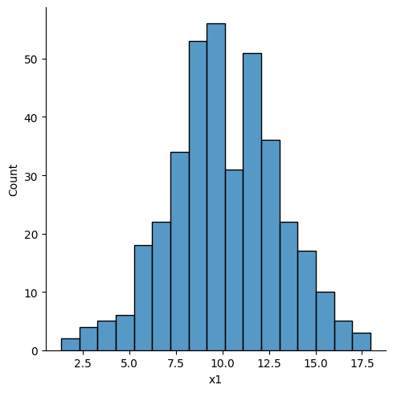

```python
sns.displot(data = df, x='x1', kind = 'hist', bins =17)
```

It does look like a bell curve

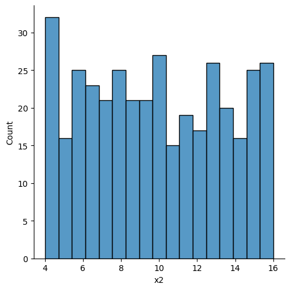

```python
sns.displot(data = df, x='x2', kind = 'hist', bins =17)
```

It does not look like a bell curve

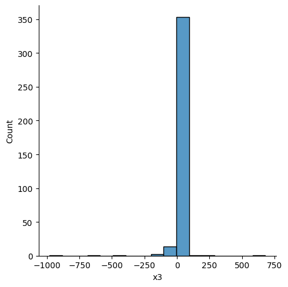

```python
sns.displot(data = df, x='x3', kind = 'hist', bins =17)
```

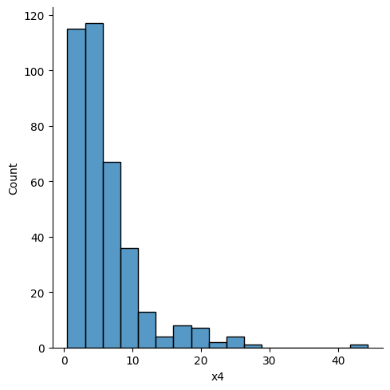

```python
sns.displot(data = df, x='x4', kind = 'hist', bins =17)
```

It does not look like a bell curve

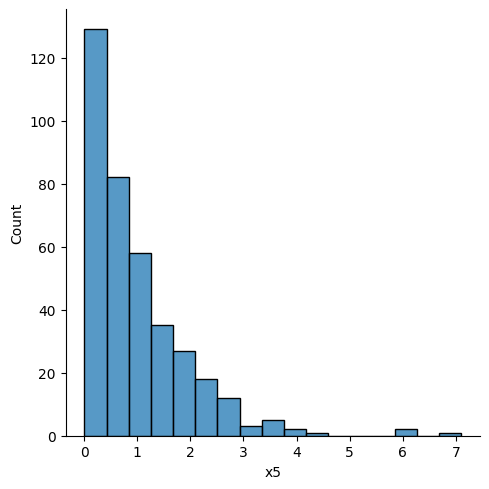

```python
sns.displot(data = df, x='x5', kind = 'hist', bins =17)
```

It does not look like a bell curve

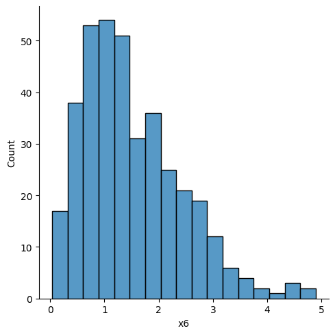

```python
sns.displot(data = df, x='x6', kind = 'hist', bins =17)
```

It does not look like a bell curve

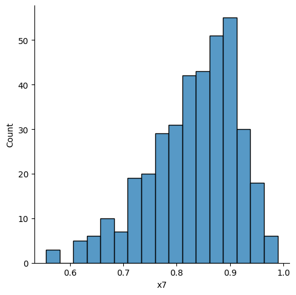

```python
sns.displot(data = df, x='x7', kind = 'hist', bins =17)
```

It almost looks like a bell curve

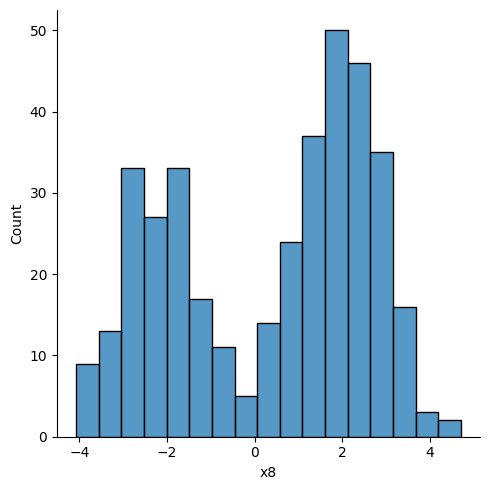

```python
sns.displot(data = df, x='x8', kind = 'hist', bins =17)
```

It does not look like a bell curve

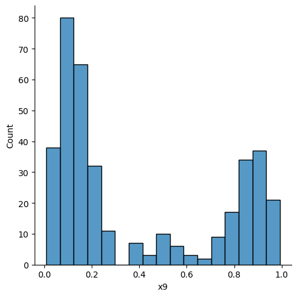

```python
sns.displot(data = df, x='x9', kind = 'hist', bins =17)
```

It does not look like a bell curve

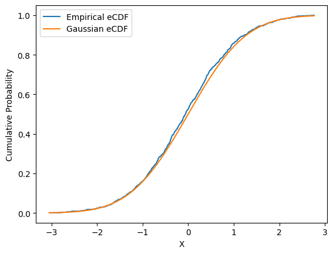

```python
import numpy as np
import matplotlib.pyplot as plt
from scipy import stats

# Generate a random dataset
np.random.seed(0)
data = np.random.normal(loc=0, scale=1, size=1000)

# Calculate the eCDF of the dataset
ecdf = stats.cumfreq(data, numbins=1000)
x = ecdf.lowerlimit + np.linspace(0, ecdf.binsize * ecdf.cumcount.size, ecdf.cumcount.size)

# Plot the empirical eCDF
plt.plot(x, ecdf.cumcount / len(data), label='Empirical eCDF')

# Generate the theoretical Gaussian eCDF
gaussian_ecdf = stats.norm.cdf(x, loc=0, scale=1)

# Plot the Gaussian eCDF
plt.plot(x, gaussian_ecdf, label='Gaussian eCDF')

# Add labels and legend
plt.xlabel('X')
plt.ylabel('Cumulative Probability')
plt.legend()

# Show the plot
plt.show()
```

Above is how a Gaussian eCDF looks like

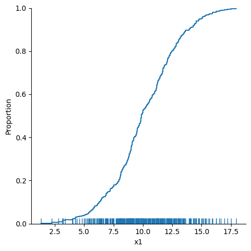

```python
sns.displot(data = df, x='x1', kind = 'ecdf', rug = True)
plt.show()
```

Looks like a Gaussian eCDF

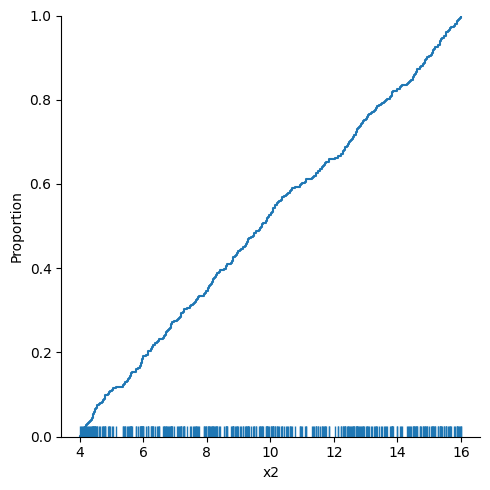

```python
sns.displot(data = df, x='x2', kind = 'ecdf', rug = True)
plt.show()
```

Does not look like a Gaussian eCDF

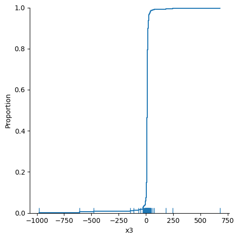

```python
sns.displot(data = df, x='x3', kind = 'ecdf', rug = True)
plt.show()
```

Does not look like a Gaussian eCDF

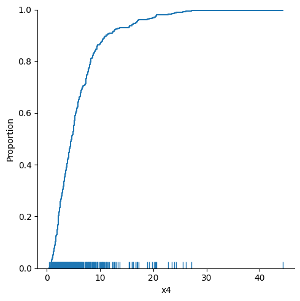

```python
sns.displot(data = df, x='x4', kind = 'ecdf', rug = True)
plt.show()
```

Does not look like a Gaussian eCDF

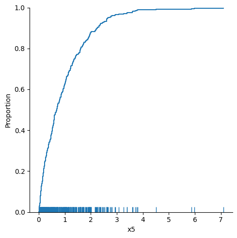

```python
sns.displot(data = df, x='x5', kind = 'ecdf', rug = True)
plt.show()
```

Does not look like a Gaussian eCDF

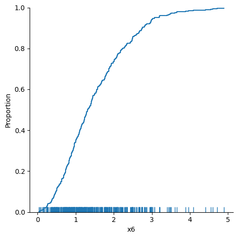

```python
sns.displot(data = df, x='x6', kind = 'ecdf', rug = True)
plt.show()
```

Does not look like a Gaussian eCDF

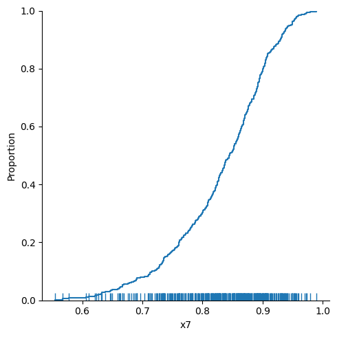

```python
sns.displot(data = df, x='x7', kind = 'ecdf', rug = True)
plt.show()
```

Almost looks like a Gaussian eCDF

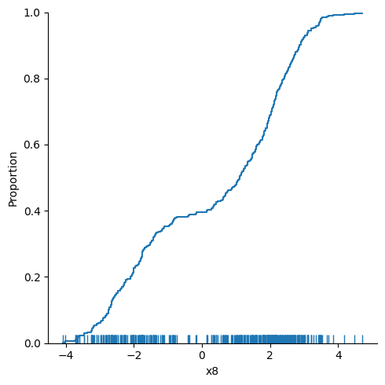

```python
sns.displot(data = df, x='x8', kind = 'ecdf', rug = True)
plt.show()
```

Does not look like a Gaussian eCDF

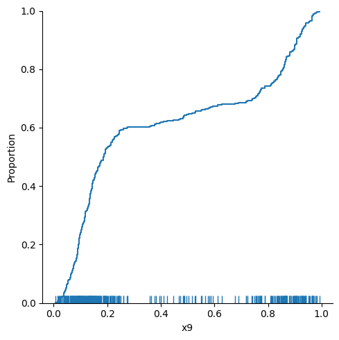

```python
sns.displot(data = df, x='x9', kind = 'ecdf', rug = True)
plt.show()
```

Does not look like a Gaussian eCDF

```python
### Add as many cells as you feel are necessary
```

## Problem 06

Now it’s time to start exploring a data set of your own choosing! Last assignment you considered several potential data sets for your final project. You may use one of those here or you can use a different data set for this problem. It is up to you!

Regardless of your choice of data set, you must perform the following actions:

- Read in the data
- Show the number of rows and columns
- Show the data types associated with the variables
- Show the number of unique values for each variable
- Show the number of MISSING values for each variable

You must create figures to start exploring the data. However, you do not need to explore ALL variables in this assignment. This is just to get you started!

The requirements depend on the variables in your data. Please see the bullets below for what is required.

- If you have at least 3 categorical variables and at least 3 continuous variables:
  - Create bar charts for 3 categorical variables of your choosing
  - Create histograms for 3 continuous variables of your choosing
- If you only have continuous variables:
  - Create histograms of 6 continuous variables
  - If you have less than 6 variables, make histograms for ALL variables
- If you only have categorical variables:
  - Create bar charts for 6 categorical variables
  - If you have less than 6 variables, make bar charts for ALL variables
- If you have less than 3 categorical variables:
  - Create bar charts for all categorical variables
  - Create histograms for at most 4 continuous variables
- If you have less than 3 continuous variables:
  - Create bar charts for at most 4 categorical variables
  - Create histograms for all continuous variables

The number of bins in the histograms should be appropriate based on the sample size.

**If you are having issues reading the data into Pandas please contact Dr. Yurko right away!!!!!!**

#### SOLUTION

```python
lovoo_v3 = pd.read_csv('lovoo_v3_users_instances.csv')
```

```python
num_rows, num_cols = lovoo_v3.shape
```

```python
num_rows
```

```
2919
```

```python
num_cols
```

```
39
```

```python
lovoo_v3.isnull()
```

[output not shown]

2919 rows × 39 columns

```python
lovoo_v3.isnull().sum()
```

```
gender                       0
age                          0
name                         0
counts_pictures              0
counts_profileVisits         0
counts_kisses                0
flirtInterests_chat          0
flirtInterests_friends       0
flirtInterests_date          0
connectedToFacebook          0
isVIP                        0
isVerified                   0
lastOnline                   1
lastOnlineTs                 1
lang_count                   0
lang_fr                      0
lang_en                      0
lang_de                      0
lang_it                      0
lang_es                      0
lang_pt                      0
city                       209
locationCity                10
locationCitySub           2851
userInfo_visitDate        2907
countDetails                 0
crypt                        0
flirtstar                    0
freshman                     0
hasBirthday                  0
highlighted                  0
distance                     0
locked                       0
mobile                       0
online                       0
whazzup                   1173
pictureId                    0
userId                      62
isSystemProfile              0
dtype: int64
```

```python
unique_counts = lovoo_v3.nunique()
unique_counts
```

```
gender                       1
age                         11
name                      2182
counts_pictures             31
counts_profileVisits      2169
counts_kisses              596
flirtInterests_chat          2
flirtInterests_friends       2
flirtInterests_date          2
connectedToFacebook          1
isVIP                        2
isVerified                   2
lastOnline                2670
lastOnlineTs              2670
lang_count                   9
lang_fr                      2
lang_en                      2
lang_de                      2
lang_it                      2
lang_es                      2
lang_pt                      2
city                      1116
locationCity              1368
locationCitySub             20
userInfo_visitDate           7
countDetails                36
crypt                        2
flirtstar                    2
freshman                     2
hasBirthday                  2
highlighted                  2
distance                   868
locked                       2
mobile                       2
online                       2
whazzup                   1599
pictureId                 2919
userId                    2840
isSystemProfile              2
dtype: int64
```

[output not shown]

[output cut: 137 more lines]

[output not shown]

[figure not shown]

```python
sns.catplot(data = lovoo_v3, y='name', kind='count', aspect=1.75,
            order = lovoo_v3.name.value_counts(ascending=True).index)

plt.show()
```

- If you have at least 3 categorical variables and at least 3 continuous variables:
  - Create bar charts for 3 categorical variables of your choosing
  - Create histograms for 3 continuous variables of your choosing

[output not shown]

[output cut: 137 more lines]

[output not shown]

[figure not shown]

```python
sns.catplot(data = lovoo_v3, x ='name', kind = 'count', aspect = 3)
plt.show()
```

[output not shown]

[output cut: 137 more lines]

[output not shown]

[figure not shown]

```python
sns.catplot(data = lovoo_v3, y ='name', kind = 'count', aspect = 3)
plt.show()
```